# Report Assessment Ch5 Subsidies Reform

Data Management Report

Author

Affiliation

Rainer M. Krug

[Senckenberg](https://www.senckenberg.de/en/institutes/sbik-f/)

Doi

Abstract

## Working Title

IPBES_TCA_Ch5_Subsidies_Reform

## Code repo

[Github - private](https://github.com/IPBES-Data/IPBES_TCA_Ch5_Subsidies_Reform)

## Build No: 72

# Introduction

### The following steps will be done in documented in this report:

- Do asearch with `R1_st` and `R2_st` and determine the number of hits
- Should the copplete `**R1** AND **R2**` be downloaded, or only a random subsets?

# Methods

The search terms are based on the [shared google doc](https://docs.google.com/document/d/1_FmxYVhpv2Bu2Gbbxb7cWc49f3soFvc64Qau_x2RAqI). They are cleaned up for the usage in [OpenAlex](https://openalex.org/).

## `R1` count from OpenAlex

The search terms is R1

```r
#|

R1_count <- sapply(
    R1_st,
    function(st) {
        openalexR::oa_fetch(
            title_and_abstract.search = compact(st),
            count_only = TRUE,
            verbose = TRUE
        )[, "count"]
    }
) |>
    sum()
```

## `R2` count from OpenAlex

The search terms is R2

```r
#|

R2_count <- openalexR::oa_fetch(
    title_and_abstract.search = compact(R2_st),
    count_only = TRUE,
    verbose = TRUE
)[, "count"]
```

## `R1 AND R2` count from OpenAlex

The search term is R1 AND R2

```r
#|

R1_R2_count <- sapply(
    R1_st,
    function(st) {
        openalexR::oa_fetch(
            title_and_abstract.search = compact(paste0("(", st, ") AND (", R2_st, ")")),
            count_only = TRUE,
            output = "list",
            verbose = TRUE
        )$count
    }
) |>
    sum()
```

## Download `R1 AND R2` Corpus

The corpus download will be stored in `data/pages` and the arrow database in `data/corpus`.

This is not on github!

The corpus can be read by running `read_corpus()` which opens the database so that then it can be fed into a `dplyr` pipeline. After most `dplyr` functions, the actual data needs to be collected via `dplyr::collect()`.

Only then is the actual data read!

Needs to be enabled by setting `eval: true` in the code block below.

```r
#|

tic()

get_corpus_pages <- function(search, pages_dir, rds_dir = "pages_publication_year=") {
    dir.create(
        path = pages_dir,
        showWarnings = FALSE,
        recursive = TRUE
    )

    years <- oa_fetch(
        title_and_abstract.search = compact(search),
        group_by = "publication_year",
        paging = "cursor",
        verbose = FALSE
    )$key

    #######
    #######
    # processed <- list.dirs(
    #     path = pages_dir,
    #     full.names = FALSE,
    #     recursive = FALSE
    # ) |>
    #     gsub(
    #         pattern = paste0("^pages_publication_year=", ""),
    #         replacement = ""
    #     )

    # interrupted <- list.files(
    #     path = pages_dir,
    #     pattern = "^next_page.rds",
    #     full.names = TRUE,
    #     recursive = TRUE
    # ) |>
    #     gsub(
    #         pattern = paste0("^", pages_dir, "/pages_publication_year=", ""),
    #         replacement = ""
    #     ) |>
    #     gsub(
    #         pattern = "/next_page.rds$",
    #         replacement = ""
    #     )

    # completed <- processed[!(processed %in% interrupted)]

    # years <- years[!(years %in% completed)]
    #######
    #######

    result <- pbmcapply::pbmclapply(
        sample(years),
        function(y) {
            message("\nGetting data for year ", y, " ...")
            output_path <- file.path(pages_dir, paste0(rds_dir, y))

            dir.create(
                path = output_path,
                showWarnings = FALSE,
                recursive = TRUE
            )

            data <- oa_query(
                title_and_abstract.search = compact(search),
                publication_year = y,
                options = list(
                    select = c("id", "doi", "authorships", "publication_year", "display_name", "abstract_inverted_index", "topics")
                ),
                verbose = FALSE
            ) |>
                IPBES.R::oa_request_IPBES(
                    count_only = FALSE,
                    output_path = output_path,
                    verbose = TRUE
                )
        },
        mc.cores = 8,
        mc.preschedule = FALSE
    ) |>
        unlist()

    invisible(result)
}

sts <- sapply(
    R1_st,
    function(st) {
        compact(paste0("(", st, ") AND (", R2_st, ")"))
    }
)


get_corpus_pages(
    search = sts[[1]],
    pages_dir = file.path(".", "data", "pages"),
    rds_dir = "pages_1_publication_year="
)


get_corpus_pages(
    search = sts[[2]],
    pages_dir = file.path(".", "data", "pages"),
    rds_dir = "pages_2_publication_year="
)


toc()
```

The fields `author` and `topics` are serialized in the arrow database and need to be unserialized by using `unserialize_arrow()` on a dataset containing the two columns.

```r
tic()

pages_dir <- file.path(".", "data", "pages")
arrow_dir <- file.path(".", "data", "corpus")


years <- list.dirs(
    path = pages_dir,
    full.names = TRUE,
    recursive = FALSE
) |>
    strsplit(
        split = "="
    ) |>
    sapply(
        FUN = function(x) {
            x[2]
        }
    ) |>
    unique() |>
    sort()

# years_done <- list.dirs(
#     path = arrow_dir,
#     full.names = TRUE,
#     recursive = FALSE
# )

# years <- years[
#     (
#         gsub(
#             x = years,
#             pattern = paste0("^", pages_dir, "/pages_publication_year="),
#             replacement = ""
#         ) # %in% gsub(
#         #     x = years_done,
#         #     pattern = paste0("^", arrow_dir, "/publication_year="),
#         #     replacement = ""
#         # )
#     )
# ]

result <- pbapply::pblapply(
    sample(years),
    function(year) {
        message("\n     Processing year ", year, " ...\n")
        pages <- c(
            list.files(
                path = pages_dir,
                pattern = paste0("\\.rds$"),
                full.names = TRUE,
                recursive = TRUE
            ) |>
                grep(
                    pattern = year,
                    value = TRUE
                ) |>
                grep(
                    pattern = ".*publication.*",
                    value = TRUE
                )
        )
        data <- parallel::mclapply(
            pages,
            function(page) {
                # message("Processing ", page, " ...")
                p <- readRDS(file.path(page))$results
                if (length(p) == 0) {
                    p <- NULL
                } else {
                    p <- openalexR::works2df(p, verbose = FALSE)
                    p$author_abbr <- IPBES.R::abbreviate_authors(p)
                }
                return(p)
            },
            mc.cores = 1 # params$mc.cores
        ) |>
            do.call(what = dplyr::bind_rows) |>
            distinct(id, .keep_all = TRUE)

        saveRDS(
            data,
            file = file.path(pages_dir, paste0(year, ".rds"))
        )

        data <- serialize_arrow(data)

        arrow::write_dataset(
            data,
            path = arrow_dir,
            partitioning = "publication_year",
            format = "parquet",
            existing_data_behavior = "overwrite"
        )
    }
)

arrow_dir <- file.path(".", "data", "corpus_tca")

read_corpus("data/corpus") |>
    dplyr::collect() |>
    dplyr::filter(id %in% readRDS("data/ids_subs_tca.rds")) |>
    arrow::write_dataset(
        path = arrow_dir,
        partitioning = "publication_year",
        format = "parquet",
        existing_data_behavior = "overwrite"
    )

toc()
```

## Identify Works in Subsidies Corpus AND TCA corpus

```r
#|

ids_subsidies <- read_corpus(file.path("data", "corpus")) |>
    dplyr::select(id) |>
    collect() |>
    unlist()
ids_tca <- read_corpus(file.path("..", "IPBES_TCA_Corpus", "data", "corpus")) |>
    dplyr::select(id) |>
    collect() |>
    unlist()
ids_subs_tca <- ids_tca[ids_tca %in% ids_subsidies]

saveRDS(ids_subs_tca, file = file.path("data", "ids_subs_tca.rds"))
```

## Export data for sentiment analysis

```r
#|

read_corpus("data/corpus") |>
    dplyr::select(id, publication_year, ab) |>
    dplyr::collect() |>
    write.table(file = "sent_analysis_subsidies.txt")

read_corpus("data/corpus_tca") |>
    dplyr::select(id, publication_year, ab) |>
    dplyr::collect() |>
    write.table(file = "sent_analysis_subsidies_tca.txt")
```

## Export 50 random papers for manual analysis

```r
#|

set.seed(13)

read_corpus("data/corpus") |>
    dplyr::select(id, doi, author_abbr, display_name, ab) |>
    dplyr::rename(abstract = ab, title = display_name) |>
    dplyr::slice_sample(n = 50) |>
    dplyr::collect() |>
    writexl::write_xlsx(path = "random_50_subsidies.xlsx")

set.seed(14)

read_corpus("data/corpus_tca") |>
    dplyr::select(id, doi, author_abbr, display_name, ab) |>
    dplyr::rename(abstract = ab, title = display_name) |>
    dplyr::slice_sample(n = 50) |>
    dplyr::collect() |>
    writexl::write_xlsx(path = "random_50_subsidies_in_tca.xlsx")
```

# Results

### Number of hits

The number of hits are hits of the terms of the whole of the OpenAlex corpus. Due to methodological issues, the number of `R1 AND R2` are overestimates and contain some double counting.

- **`R1`** in OpenAlex: 114,186 hits
- **`R2`** in OpenAlex: 34,396,032 hits
- **`R1 AND R2`**: in OpenAlex 40,883 hits
- **`R1 AND R2`** in TCA corpus: 12,095 hits

### Publications over time

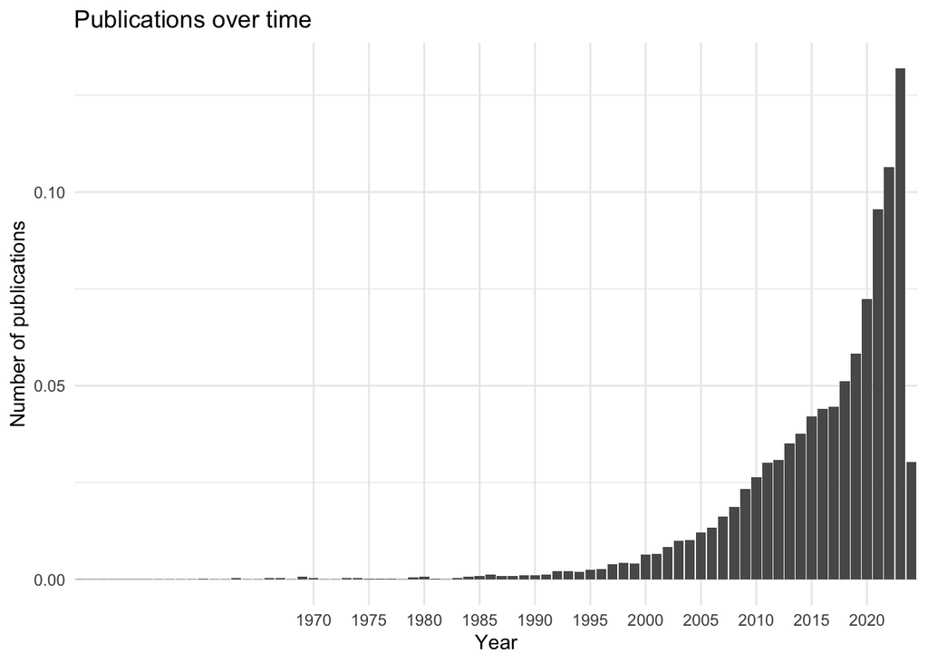

```r
read_corpus(file.path("data", "corpus_tca")) |>
    dplyr::select(publication_year) |>
    arrange(publication_year) |>
    dplyr::collect() |>
    table() |>
    as.data.frame() |>
    mutate(
        p = Freq / sum(Freq),
        p_cum = cumsum(p)
    ) |>
    ggplot() +
    geom_bar(aes(x = as.factor(publication_year), y = p), stat = "identity") +
    labs(
        title = "Publications over time",
        x = "Year",
        y = "Number of publications"
    ) +
    scale_x_discrete(breaks = seq(1970, 2020, 5)) +
    theme_minimal()
```

### Map first author affiliation

Distribution of the first author affiliation countries

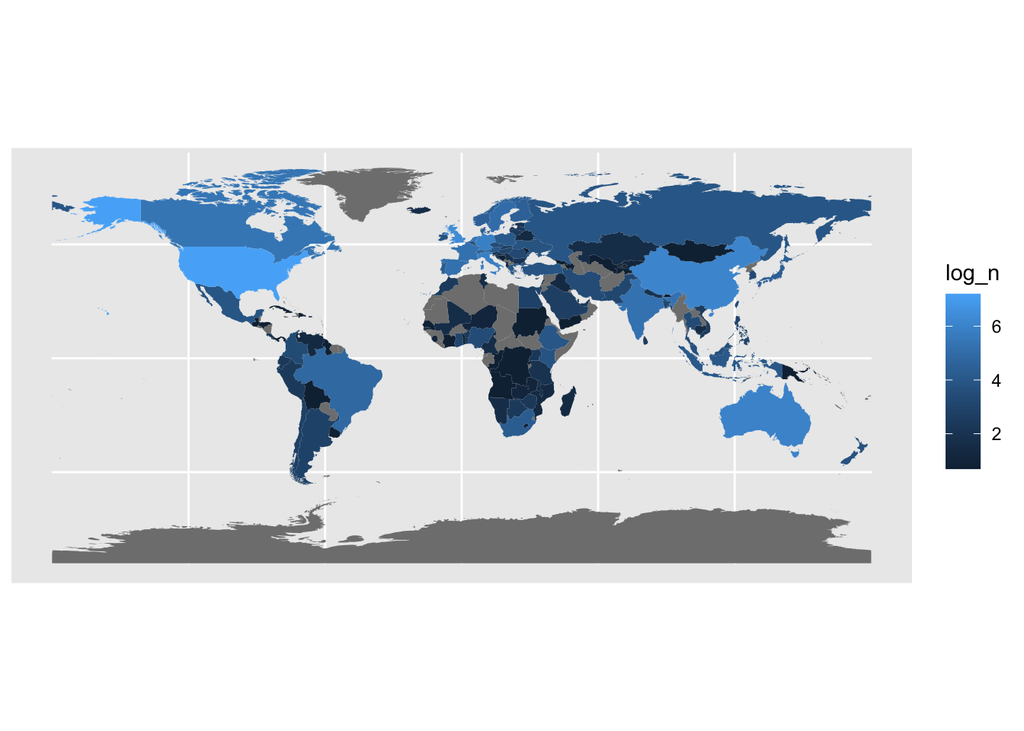

```r
dat <- read_corpus(file.path("data", "corpus_tca")) |>
    dplyr::select(author) |>
    collect()
sapply(
    dat$author,
    function(x) {
        auth <- ifelse(
            is.na(x),
            NA,
            purrr::map(x, ~ .x |>
                base64enc::base64decode() |>
                unserialize())
        )
        if (is.na(auth)) {
            return(NULL)
        } else {
            return(auth[[1]]$institution_country_code[[1]])
        }
    }
) |>
    unlist() |>
    table() |>
    as.data.frame() |>
    rename(
        iso2c = Var1,
        n = Freq
    ) |>
    mutate(
        log_n = log(n + 1)
    ) |>
    IPBES.R::map_country_codes(
        values = "log_n"
    )
```